# Flexible Bayesian modelling and causal inference for panel data with R package dynamite

2022-12-02

## Panel data

- Data from \(N\) subjects
- Measured over multiple time points \(1,\ldots,T\)
  - Can be calendar time, age, some other variable defining the order of observations
- Multiple measurements per subject, e.g., person’s yearly income, health status, partnership status, …
- Common in many fields such as econometrics, psychology and social sciences in general.
- Often used for observational causal inference

## Statistical methods

- Several modelling approaches, depending on the observed and assumed characteristics of the data
- Traditional approaches are based on some variant of cross-lagged panel model (CLPM) (e.g., Allison, Williams, and Moral-Benito 2017; Hamaker, Kuiper, and Grasman 2015) \[ y_{it} = \alpha^y_i + \beta^y_{y} y_{it-1} + \beta^y_{x} x_{it-1} + \epsilon^y_{it}\\ x_{it} = \alpha^x_i + \beta^x_{y} y_{it-1} + \beta^x_{x} x_{it-1} + \epsilon^x_{it}\\ \] where \(\epsilon^y_t\) and \(\epsilon^x_t\) follow normal distribution.
- Estimation is typically based on maximum likelihood using structural equation models (SEM)
- Other fixed “control variables” can also be included in both equations

## Cross-lagged panel model with two variables

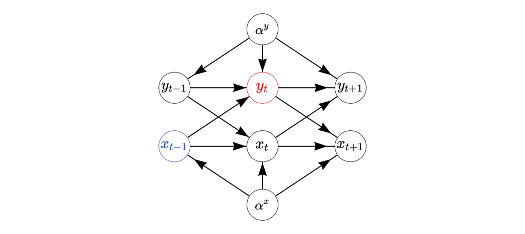

Directed acyclic graph (DAG) of bivariate CLPM

## Limitations of CLPM

- SEM approaches assume joint normality of the response variables
  - Traditional implementations can only handle few time points (e.g. < 50)
- All effects are assumed to be constant in time
  - Reasonable for small \(T\), not necessarily so for larger \(T\)
- Focus on one-step-ahead effect based on the model parameters
  - Effects of interventions might not persists over time (not the same as previous point!)

## Time-varying effects

- It is possible that the effects of some predictors change over time
- Effects of policy changes can slowly diminish or take some time to fully affect the behavior of all individuals
  - introduction of traffic cameras could first reduce the overall speeding until people learn where the cameras are located
- Unmeasured changes in individuals’ common environment can also cause the parameters to vary in time (if allowed to do so)
  - Can be used to assess the effects of unobserved (time-varying) confounding

## Time-varying regression

- In state space modelling approaches the coefficients vary according to (integrated) random walks
  - Can become computationally demanding with large number of individuals, especially in non-Gaussian setting
  - (Mostly) outside of panel data setting (e.g., Helske 2022; Harvey and Phillips 1982) but proposed already in (Harvey 1978)
- Varying coefficients models based on kernel smoothing and splines (e.g., `tvReg` and `tvem` R packages)
  - Choosing bandwidth or number of knots can be challenging

## Long-term causal effects (LTCE)

- Instead of focusing on the causal effect of \(x_t\) on \(y_{t+1}\), it might be of interest to consider the effects of
- atomic intervention \(p(y_{t+k} | do(x_t = x))\), \(k=1,\ldots\) and
- recurring intervention \(p(y_{t+k} | do(x_t = x,\ldots, x_{t+k} = x))\),\(k \geq 1\).

## Example of estimating LTCEs

- Consider a situation in the following graph, from which we want to estimate causal effect of \(x_{1}\) on \(y_{3}\)

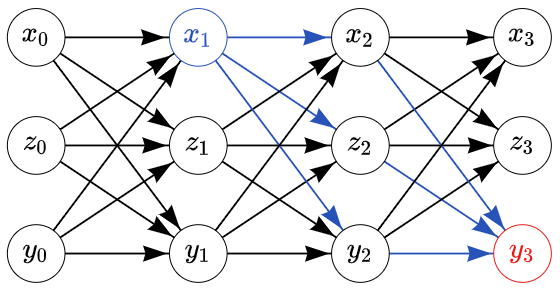

## Identifying functional

- Nonparametric identifying functional for the interventional distribution \(p(y_{3} | do(x_{1}))\): \[ \sum_{z_{1},y_{1}}p(y_{3}|x_{1},z_{1},y_{1})p(z_{1},y_{1}) \]
- Familiar form of back-door adjustment (Pearl 2009)
- We need to estimate distributions \(p(y_{3}|x_{1},z_{1},y_{1})\) and \(p(z_{1},y_{1})\)
- \(p(z_{1},y_{1})\) can be estimated based on the empirical distribution of our data, e.g., summing over our \(N\) individuals (Hernán and Robins 2020).

## Alternative identifying functional

- Could construct a statistical model directly for the distribution \(p(y_{3}|x_{1},z_{1},y_{1})\)
- Say we are also interested in \(p(y_{4} | do(x_{1}))\). Now we should estimate a new model for \(p(y_{4}|x_{1},z_{1},y_{1})\).
- Fortunately we have an equivalent identifying functional \[ \sum_{z_{1},y_{1}, x_{2}, z_{2}, y_{2}}p(y_{3}|x_{2},z_{2},y_{2})p(x_2, z_2, y_2 | x_1, z_1, y_1)p(z_{1},y_{1}) \]
- Enough to model the relationship of observations at time \(t\) given the previous time point(s).

## Estimating LTCE

- For \(j=1,\ldots, M\) (number of posterior samples)
  - For \(i=1,\ldots,N\) (number of individuals)
    - Simulate \((x^j_{i,2}, z^j_{i,2}, y^j_{i,2}) \sim p(x_{i,2}, z_{i,2}, y_{i,2} | x_{1}, z_{i,1}, y_{i,1}, \theta^j)\)
    - Simulate \(y^j_{i,3} \sim p( y_{i,3} | x^j_{i,2}, z^j_{i,2}, y^j_{i,2}, \theta^j)\)
- Now \(y^j_{i,3}\) are posterior samples from \(p(y_{3} | do(x_{1}))\).
- Replacing the simulation of \(y^j_{i,3}\) with \(E(y_{i,3} | x^j_{i,2}, z^j_{i,2}, y^j_{i,2}, \theta^j)\) and averaging over individuals leads to samples from the posterior distribution of the average causal effect \(E(y_{3} | do(x_{1}))\)

## Dynamite model

- \(C\) response variables (*channels*), \(y_{it} = (y^1_{it},\ldots,y^C_{it})\)
- \(y_{i,t}\) can depend on the past values \(y_{i,t-k}\), \(k=1,\ldots\) and exogenous variables \(x_{i,t-k}\), \(k=0,\ldots\)
- \(k\) can be different for different channels, today \(k=1\) for simplicity
- We have \[ p_t(y_{i,t} | y_{i,t-1}) = \prod_{c=1}^C p^c_t(y^c_{i,t} | y^1_{i,t-1}, \ldots, y^C_{i,t-1}), \]
- The first \(k\) time points are treated as fixed data.
- `dynamite` currently supports Gaussian, Categorical, Poisson, Binomial, Bernoulli, Negative Binomial, Gamma, Exponential and Beta distributions

## Linear predictor

- We define a linear predictor \(\eta^c_{i,t}\) for the channel \(c\) with a following general form: \[ \eta^c_{i,t} = \alpha^c_{t} + \nu^c_{i} + \lambda^c_i\psi^c_t +X^c_{i,t} \beta^c + Z^c_{i,t} \delta^c_{t} \]
- \(\alpha_t\) is the common, possibly time-varying, intercept term
- \(\nu^c_{i}\) are zero-mean Gaussian intercept terms, correlated across channels
- \(\lambda^c_i\psi^c_t\) corresponds to latent dynamic factor and its loadings
- \(\beta^c\) are time-invariant coefficients and \(\delta^c_{t}\) are time-varying coefficients

## Time-varying components

- We define \(\delta_t\) via Bayesian penalized B-splines (Lang and Brezger 2004): \[ \begin{aligned} \delta_{t} &= B_t \omega, &\quad t=k+1,\ldots, T\\ \omega_d &\sim N(\omega_{d-1}, \tau^2), &\quad d=2,\ldots,D \end{aligned} \] where \(B_t\) are the B-spline basis function values at time \(t\) and vector \(\omega\) contains spline coefficients.
- Random walk prior on \(\omega\) defines the smoothness of the spline
- \(\tau \to 0\) leads to a time-invariant effect
- Prior on \(\omega_1\) = prior on \(\delta_1\)

## Latent factors

- Instead of common time-varying intercept \(\alpha_t\), we can estimate a common latent factor \(\psi^c_t\) and individual-specific factor loadings \(\lambda^c_i\)
- Factors can be correlated across channels
- I will skip these today

## Dynamite graph

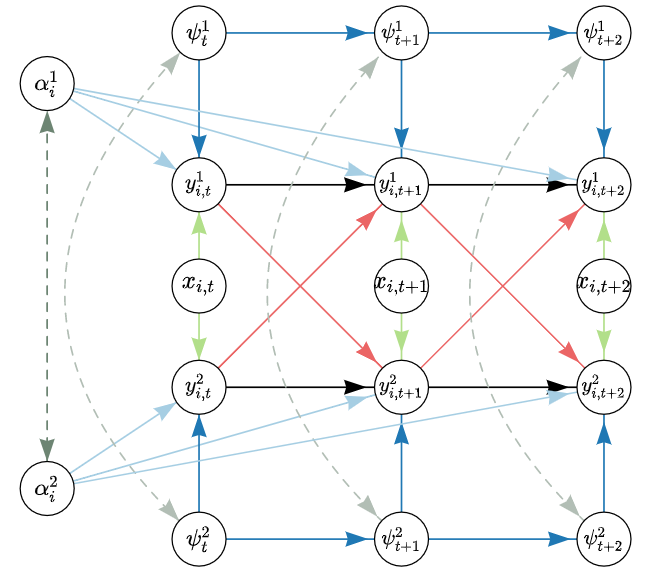

## Causal effect of employment on employment

- Data on 845 individuals from Swiss Household Panel
- 13 time points, from ages 20 to 44 (every two years)
- Binary variables `gender` (421/424 females/males) and `fulltime`, whether the person was employed full time or not
- Data included in the R package `march`
- Interested in how intervention on employment at the age of 30 affects the future employment status

## Causal graph

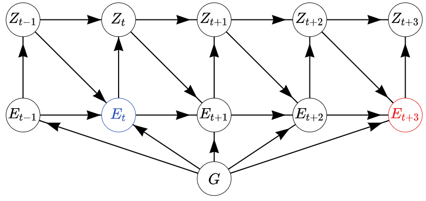

## Defining the model in R

```r
model_formula <-
  obs(fulltime ~
      gender +
      varying(~ -1 + gender:lag(never) + gender:lag(fulltime)),
    family = "bernoulli") +
  aux(never ~ fulltime == 0 & lag(never) == 1 | init(1)) +
  splines(df = 10)
)
fit <- dynamite(model_formula, data = d, group = "id", time = "age",
  chains = 4, cores = 4, iter = 2000)
```

## Time-varying effects

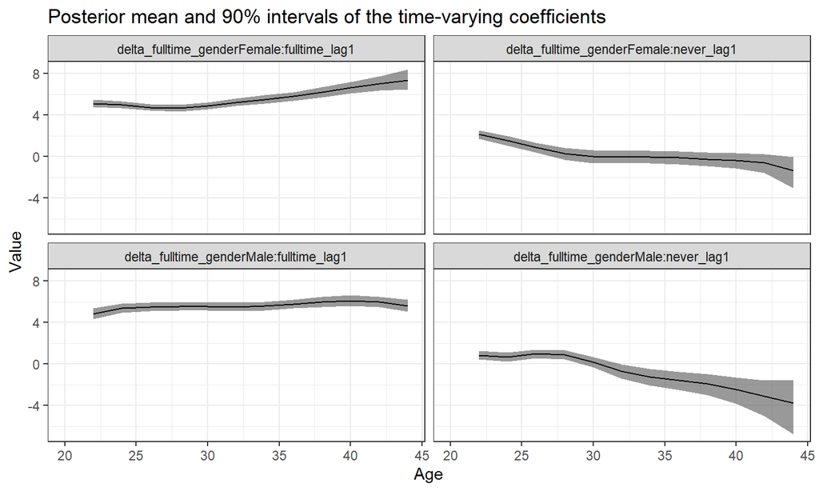

```r
plot_deltas(fit) + xlab("Age") + theme_bw()
```

## Simulation of individual trajectories based on the intervention

```r
# No full time employment at age 30
newdata0 <- d |> filter(age >= 28)
newdata0$fulltime[newdata0$age == 30] <- 0
newdata0$fulltime[newdata0$age > 30] <- NA
# Full time employment at age 30
newdata1 <- d |> filter(age >= 28)
newdata1$fulltime[newdata1$age == 30] <- 1
newdata1$fulltime[newdata1$age > 30] <- NA
```

## Predictions cont.

```r
pred <-
  bind_rows(
    no = predict(fit, newdata = newdata0,
      funs = list(fulltime = list(mean = mean)))$simulated,
    yes = predict(fit, newdata = newdata1,
      funs = list(fulltime = list(mean = mean)))$simulated,
    .id = "fulltime_30"
  ) |> filter(age > 28) |>
  group_by(age) |>
  summarise(difference =
      mean_fulltime[fulltime_30 == "yes"] -
      mean_fulltime[fulltime_30 == "no"]
  ) |>
  summarise(
    mean = mean(difference),
    lwr = quantile(difference, 0.025),
    upr = quantile(difference, 0.975)
  )
```

## Results

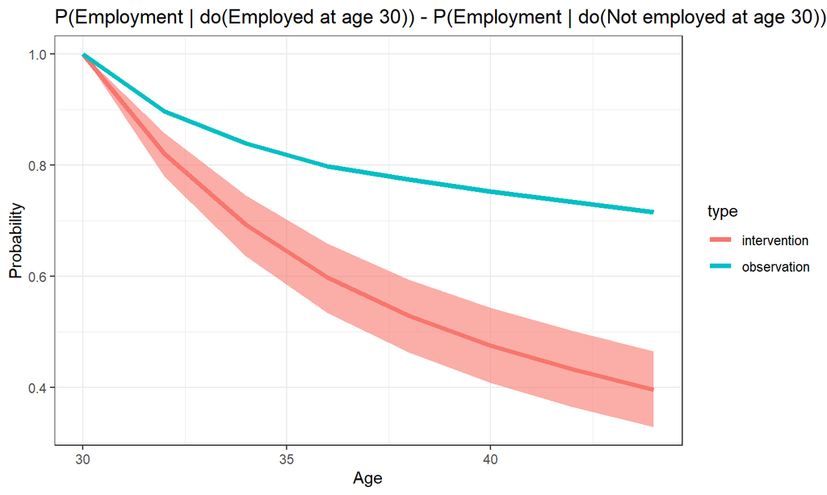

## Future directions

- Support for group-level regression coefficients
- Ordinal and t-distributions
- Case studies

The `dynamite` package can be installed from github via

```r
devtools::install_github("santikka/dynamite")
```

## The end

Allison, P D, R Williams, and E Moral-Benito. 2017. “Maximum Likelihood for Cross-Lagged Panel Models with Fixed Effects.” *Socius*.

Hamaker, E L, R M Kuiper, and R PPP Grasman. 2015. “A Critique of the Cross-Lagged Panel Model.” *Psychological Methods*.

Harvey, A C. 1978. “The Estimation of Time-Varying Parameters from Panel Data.” In *Annales de l’inséé*.

Harvey, A C, and G D A Phillips. 1982. “The Estimation of Regression Models with Time- Varying Parameters.” In *Games, Economic Dynamics, and Time Series Analysis*, edited by M. Deistler, E. Fürst, and G. Schwödiauer. Heidelberg.

Helske, J. 2022. “Efficient Bayesian Generalized Linear Models with Time-Varying Coefficients: The Walker Package in R.” *SoftwareX*.

Hernán, M A, and J M Robins. 2020. *Causal Inference: What If*.

Lang, S, and A Brezger. 2004. “Bayesian P- Splines.” *Journal of Computational and Graphical Statistics*.

Pearl, J. 2009. *Causality: Models, Reasoning, and Inference*.

Sun, Y, R J Carroll, and D Li. 2009. “Semiparametric Estimation of Fixed-Effects Panel Data Varying Coefficient Models.” In *Nonparametric Econometric Methods*.